# Time Series: A First Course with Bootstrap Starter

# Lesson 3-4: Trends

- Trends measure the long-term behavior of a time series.
- Trends are steady movements in the level of a time series.
- We can use smoothers to estimate trends.
- Removing a trend by subtraction allows us to see other features.

## Example 3.4.1. Western Housing Starts Cycle

- We estimate and eliminate the trend in the Westing Housing Starts data, so that we can more clearly see the business cycle movements.

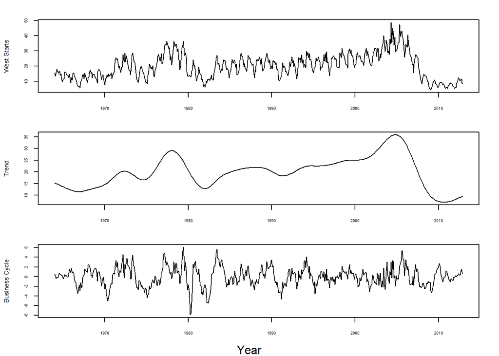

```r
hpsa <- function(n,period,q,r)
{
    # hpsa
    #     gives an HP filter for seasonal data
    #   presumes trend+seas+irreg structure
    #       trend is integrated rw
    #       seas is seasonal rw
    #       irreg is wn
    #   q is snr for trend to irreg
    #   r is snr for seas to irreg

# define trend differencing matrix

delta.mat <- diag(n)
temp.mat <- 0*diag(n)
temp.mat[-1,-n] <- -2*diag(n-1)
delta.mat <- delta.mat + temp.mat
temp.mat <- 0*diag(n)
temp.mat[c(-1,-2),c(-n,-n+1)] <- 1*diag(n-2)
delta.mat <- delta.mat + temp.mat
diff.mat <- delta.mat[3:n,]

# define seasonal differencing matrix

delta.mat <- diag(n)
temp.mat <- 0*diag(n)
inds <- 0
for(t in 1:(period-1))
{
    temp.mat <- 0*diag(n)
    temp.mat[-(1+inds),-(n-inds)] <- 1*diag(n-t)
    delta.mat <- delta.mat + temp.mat
    inds <- c(inds,t)
}
sum.mat <- delta.mat[period:n,]

# define two-comp sig ex matrices

#trend.mat <- solve(diag(n) + t(diff.mat) %*% diff.mat/q)
#seas.mat <- solve(diag(n) + t(sum.mat) %*% sum.mat/r)
trend.mat <- diag(n) - t(diff.mat) %*% solve(q*diag(n-2) + diff.mat %*%
    t(diff.mat)) %*% diff.mat
seas.mat <- diag(n) - t(sum.mat) %*% solve(r*diag(n-period+1) + sum.mat %*%
    t(sum.mat)) %*% sum.mat

# define three-comp sig ex matrices

trend.filter <- solve(diag(n) - trend.mat %*% seas.mat) %*%
    trend.mat %*% (diag(n) - seas.mat)
seas.filter <- solve(diag(n) - seas.mat %*% trend.mat) %*%
    seas.mat %*% (diag(n) - trend.mat)
irreg.filter <- diag(n) - (trend.filter + seas.filter)

filters <- list(trend.filter,seas.filter,irreg.filter)
return(filters)
}

Wstarts <- read.table("Wstarts.b1",skip=2)[,2]
Wstarts <- ts(Wstarts,start = 1964,frequency=12)
n <- length(Wstarts)
q <- .0001
r <- 1
hp.filters <- hpsa(n,12,q,r)

wstarts.trend <- hp.filters[[1]] %*% Wstarts
wstarts.seas <- hp.filters[[2]] %*% Wstarts
wstarts.cycle <- hp.filters[[3]] %*% Wstarts
wstarts.sa <- wstarts.trend + wstarts.cycle

comps <- ts(cbind(wstarts.trend,wstarts.seas,wstarts.cycle),start=1964,frequency=12)
trend <- ts(wstarts.trend,start=1964,frequency=12)
cycle <- ts(wstarts.cycle,start=1964,frequency=12)

par(oma=c(2,0,0,0),mar=c(2,4,2,2)+0.1,mfrow=c(3,1),cex.lab=.8)
plot(Wstarts, ylab="West Starts",xlab="",yaxt="n",xaxt="n")
axis(1,cex.axis=.5)
axis(2,cex.axis=.5)
plot(trend,xlab="",ylab = "Trend",yaxt="n",xaxt="n")
axis(1,cex.axis=.5)
axis(2,cex.axis=.5)
plot(cycle,xlab="",ylab = "Business Cycle",yaxt="n",xaxt="n")
axis(1,cex.axis=.5)
axis(2,cex.axis=.5)
mtext(text="Year",side=1,line=1,outer=TRUE)
```

## Paradigm 3.4.12. Nonparametric Trend Estimation

- We consider trends $\mu_t$ to be either a deterministic (but unknown) function of time, or are an unobserved stochastic process:
  $$X_t = \mu_t + Z_t.$$
  Here ${\mathbb E} [ X_t ] = \mu_t$ and $\{ Z_t \}$ is a mean zero time series.
- A *two-sided moving average* is a linear filter that can be used to estimate trends:
  $$\Psi (B) = \sum_{k = -m}^m \psi_k B^k.$$
  When all the weights are equal, this is a simple moving average. It is two-sided because the moving average uses past and future data:
  $$\widehat{\mu}_t = \Psi (B) X_t = \sum_{k= -m}^m \psi_k X_{t-k}.$$
- A *symmetric moving average* weights future and past equally, i.e., $\psi_k = \psi_{-k}$.
- As an estimator $\widehat{\mu}_t$ of the unknown trend $\mu_t$, there is less bias if $m$ is small, and less variance if $m$ is large. This is a **Bias-Variance Dilemma**.

## Paradigm 3.4.15. Trend Elimination

- We can remove a trend by subtracting off its estimate.
- We can also apply the differencing filter.
- Example with US population, detrended by a $m = 10$ simple moving average and by the difference filter.

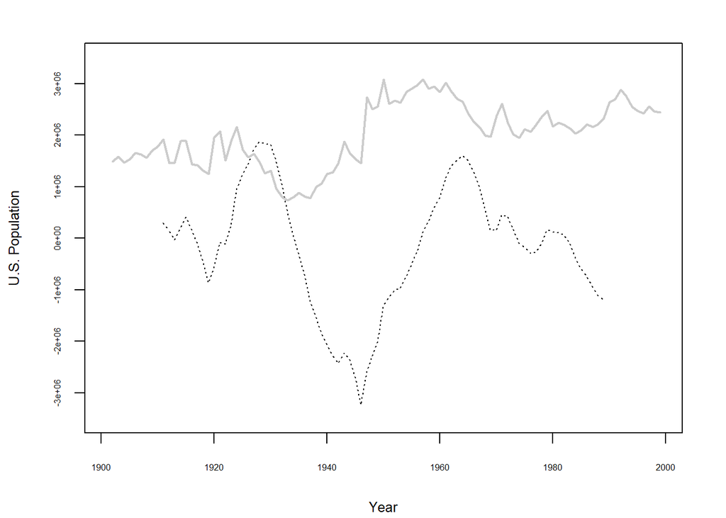

```r
pop <- read.table("USpop.dat")
pop <- ts(pop, start = 1901)

p <- 10
pop.smooth <- stats::filter(pop,rep(1,2*p+1)/(2*p+1),method="convolution")
pop.smooth <- ts(pop.smooth,start= 1901)
pop.diff <- diff(pop)

par(mar=c(4,4,2,2)+0.1,cex.lab=.8)
plot(ts(pop - pop.smooth,start=1901),lwd=1,lty=3,ylim=c(-3.5*10^6,3.5*10^6),
    ylab="U.S. Population",xlab="Year",yaxt="n",xaxt="n")
axis(1,cex.axis=.5)
axis(2,cex.axis=.5)
lines(pop.diff,col=gray(.8),lwd=2)
```